# Regression Models

B Odoi

2023-09-06

Regression is a statistical technique used for modeling the relationship between a dependent variable (also known as the target or response variable) and one or more independent variables (predictors or features).

The primary goal of regression analysis is to:

- understand and quantify the relationship between these variables and
- use it to make predictions, infer causal relationships, or estimate the effect of one variable on another.

We would consider the following regression models:

- Linear Regression
- Logistic Regression
- Polynomial Regression
- Ridge Regression and Lasso Regression
- ElasticNet Regression
- Support Vector Regression (SVR)
- Quantile Regression
- Poisson Regression
- Time Series Regression
- Nonlinear Regression
- Bayesian Regression
- Quantile Regression

### Load Required Libraries

```r
# Correlation Plots
library(ggplot2)
library(tidyverse)
library(dplyr)

# Load excel file
library(readxl)
```

### Load Dataset

```r
path_to_file <- "E:/OdoiPData/water-data.xlsx"
waterqlt_data <- read_excel(path_to_file, sheet='mean-impute')
head(waterqlt_data, 5)
```

```
## # A tibble: 5 × 20
##      pH Conductivity Total Suspended Solids at 103-105&…¹ Total Dissolved Soli…²
##   <dbl>        <dbl>                                <dbl>                  <dbl>
## 1   7.1         13.4                                    1                     92
## 2   7.6         37.2                                  496                    256
## 3   7.9         57.3                                  604                    394
## 4  12.2        265                                     71                    797
## 5   8           63                                    625                    351
## # ℹ abbreviated names: ¹`Total Suspended Solids at 103-105&#39;C`,
## #   ²`Total Dissolved Solids Dried at 180C`
## # ℹ 16 more variables: `Colour (Apparent)` <dbl>, `Colour (True)` <dbl>,
## #   `Ammonia as N` <dbl>, Chloride <dbl>, `Nitrate-Nitrogen, NO3 as N` <dbl>,
## #   `Nitrite Nitrogen, NO2 as N` <dbl>, Salinity <dbl>,
## #   `Sulphate as SO4` <dbl>, `Fluoride by ISE` <dbl>,
## #   `Calcium dissolved` <dbl>, `Magnesium dissolved` <dbl>, …
```

### Linear Regression

- Linear regression is used when there is a linear relationship between the dependent variable and one or more independent variables.
- Simple Linear Regression: One dependent variable and one independent variable.
- Multiple Linear Regression: One dependent variable and multiple independent variables.

As a professional your analysis may be used to make business decisions hence its important that you perform all necessary checks on the data you are using to model to ensure accurate model results. Here are some steps you would have to take before building your regression model:

1. **Data Exploration**:
   - Examine the data with summary statistics, histograms, and scatterplots to get a basic understanding of the variables, their distributions, and potential relationships.

     ```r
     # Select some numeric columns for the analysis
     ds <- waterqlt_data %>% select(c(Conductivity, Salinity, "Sodium dissolved",                                              Chloride))
     ```

     ```r
     # Obtain a statistical summary
     summary(ds)
     ```

     ```
     ##   Conductivity       Salinity       Sodium dissolved    Chloride
     ##  Min.   :  6.00   Min.   :0.03000   Min.   : 0.10    Min.   : 2.500
     ##  1st Qu.: 25.70   1st Qu.:0.04000   1st Qu.:15.90    1st Qu.: 5.600
     ##  Median : 37.00   Median :0.04464   Median :24.35    Median : 7.872
     ##  Mean   : 40.21   Mean   :0.04464   Mean   :24.35    Mean   : 7.872
     ##  3rd Qu.: 49.30   3rd Qu.:0.04464   3rd Qu.:24.35    3rd Qu.: 7.900
     ##  Max.   :265.00   Max.   :0.09000   Max.   :82.00    Max.   :33.800
     ```

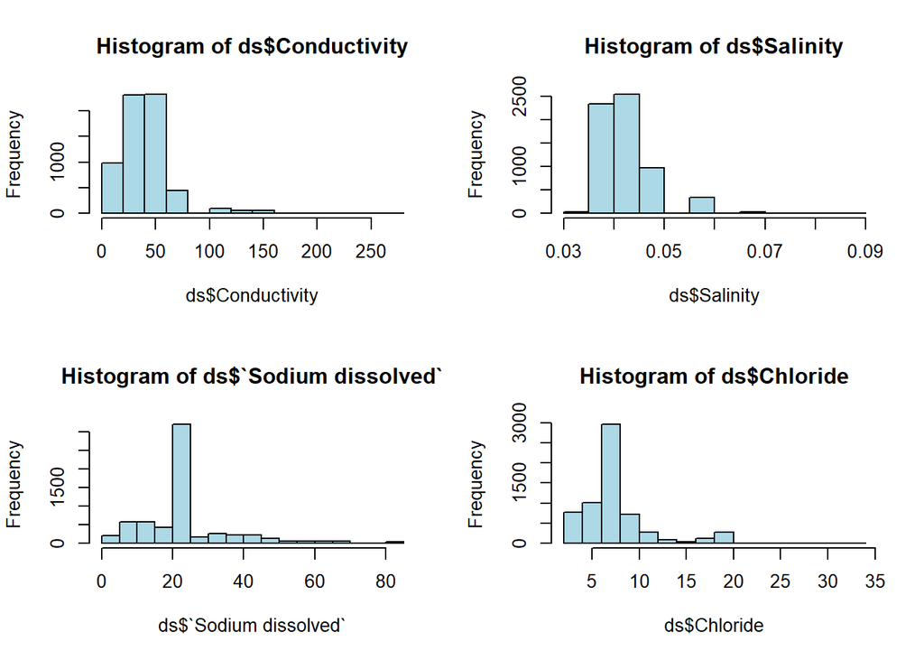

     ```r
     par(mfrow = c(2, 2))  # Set up a 2x2 grid of plots (adjust as needed)

     hist(ds$Conductivity, col = "lightblue")
     hist(ds$Salinity, col = "lightblue")
     hist(ds$`Sodium dissolved`, col = "lightblue")
     hist(ds$Chloride, col = "lightblue")
     ```

2. **Linearity**:
   - Ensure that there is a linear relationship between the dependent variable and the independent variables. You can use scatterplots or correlation matrices to check for linearity.

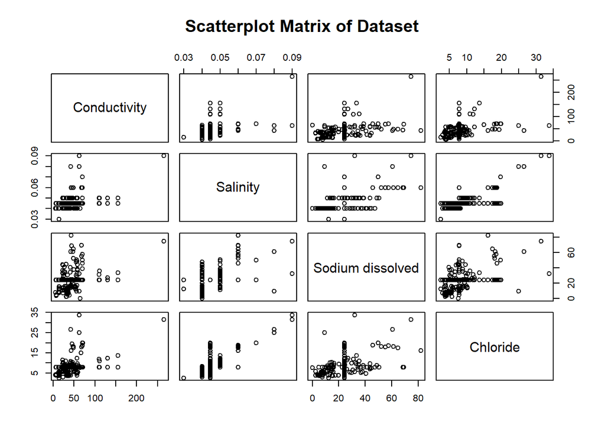

     ```r
     # Plot a scatter diagram
     pairs(ds, main = "Scatterplot Matrix of Dataset", pch = 21)
     ```

3. **Multicollinearity**:
   - Detect and address multicollinearity, which occurs when independent variables are highly correlated with each other. High multicollinearity can destabilize coefficient estimates.
   - Calculate correlation coefficients between independent variables and use variance inflation factors (VIFs) to assess multicollinearity.
4. **Outliers**:
   - Identify and handle outliers that may have a disproportionate impact on the model. Outliers can affect the regression coefficients and the model’s fit.
   - Use boxplots, scatterplots, or statistical tests (e.g., Cook’s Distance) to detect outliers.

     ```r
     #The IQR method identifies outliers as values that fall below Q1 - 1.5 * IQR or above Q3 + 1.5 * IQR, where Q1 is the first quartile and Q3 is the third quartile. Here's a function that accomplishes this:

     detect_outliers_iqr <- function(data) {
       # Initialize an empty list to store outlier indices for each column
       outlier_indices <- list()

       # Loop through each column in the dataset
       for (col in 1:ncol(data)) {
         # Calculate the quartiles and IQR for the column
         Q1 <- quantile(data[, col], 0.25, na.rm = TRUE)
         Q3 <- quantile(data[, col], 0.75, na.rm = TRUE)
         IQR <- Q3 - Q1

         # Calculate the lower and upper bounds for outliers
         lower_bound <- Q1 - 1.5 * IQR
         upper_bound <- Q3 + 1.5 * IQR

         # Find the indices of outliers in the column
         outliers <- which(data[, col] < lower_bound | data[, col] > upper_bound)

         # Store the outlier indices in the list
         outlier_indices[[col]] <- outliers
       }

       # Return a list of outlier indices for each column
       return(outlier_indices)
     }


     outlier_indices <- detect_outliers_iqr(ds)

     # Print the indices of outliers in each column
     for (col in 1:length(outlier_indices)) {
       cat("Outliers in Column", col, ": ", length(outlier_indices[[col]]), "\n")
     }
     ```

     ```
     ## Outliers in Column 1 :  197
     ## Outliers in Column 2 :  411
     ## Outliers in Column 3 :  741
     ## Outliers in Column 4 :  566
     ```

[figure not shown]

     ```r
     # Create a boxplot of residuals
     boxplot(ds, main = "Boxplot of Residuals")
     ```

The insights gained from the exploratory test will inform the

- treatment to give to the data before fitting the model.

Linear regression models can be formed with or without interaction effects

#### Linear Regression without Interaction Effect

In a standard linear regression model without interaction effects, each predictor variable (independent variable) is assumed to have a constant and independent effect on the dependent variable.

- We have 4 variables that we want to use to model
- We would use `conductivity` as the response variable `salinity`, `sodium dissolved` and `chloride` as predictors.

  **Simple Linear Regression**

  This models involves only two variables, the predicted and a predictor.

  ```r
  # Regress Conductivity with Sodium dissolved
  sreg_model <- lm(Conductivity ~ `Sodium dissolved`, data = ds)

  # model  summary
  summary(sreg_model)
  ```

  ```
  ##
  ## Call:
  ## lm(formula = Conductivity ~ `Sodium dissolved`, data = ds)
  ##
  ## Residuals:
  ##     Min      1Q  Median      3Q     Max
  ## -32.807 -15.140   0.000   8.193 194.773
  ##
  ## Coefficients:
  ##                    Estimate Std. Error t value Pr(>|t|)
  ## (Intercept)        25.68690    0.58583   43.85   <2e-16 ***
  ## `Sodium dissolved`  0.59626    0.02134   27.94   <2e-16 ***
  ## ---
  ## Signif. codes:  0 '***' 0.001 '**' 0.01 '*' 0.05 '.' 0.1 ' ' 1
  ##
  ## Residual standard error: 21.39 on 6255 degrees of freedom
  ## Multiple R-squared:  0.111,  Adjusted R-squared:  0.1108
  ## F-statistic: 780.6 on 1 and 6255 DF,  p-value: < 2.2e-16
  ```

- **Multiple Linear Regression**

[output not shown]

#### Explanation of the model summary output

- **Call**:
- Displays the call that was used to fit the linear regression model, including the formula and dataset used.
- **Residuals**:
  - Provides summary statistics for the residuals (differences between observed and predicted values):
    - Min: Minimum residual
    - 1Q: First quartile (25th percentile) of residuals
    - Median: Median (50th percentile) of residuals
    - 3Q: Third quartile (75th percentile) of residuals
    - Max: Maximum residual
- **Coefficients**:
  - Presents the estimated coefficients for each predictor variable in the model:
    - Estimate: The estimated coefficient value.
    - Std. Error: Standard error of the coefficient estimate.
    - t value: The t-statistic, which measures the number of standard errors the coefficient estimate is from zero.
    - Pr(>|t|): The p-value associated with the t-statistic, indicating the statistical significance of the coefficient.
  - Signif. codes: A set of asterisks (*) indicating the level of significance (e.g., “***” for highly significant).
- **Residual standard error**:
  - Provides an estimate of the standard deviation of the residuals. It represents the typical magnitude of the model’s prediction errors.
- **Multiple R-squared**:
  - Measures the proportion of variance in the dependent variable (Y) explained by the model’s predictors. Higher values indicate better fit.
  - Adjusted R-squared: A version of R-squared that adjusts for the number of predictors. It penalizes the addition of unnecessary variables.
- **F-statistic and p-value**:
  - The F-statistic assesses whether the overall regression model is statistically significant.
  - The p-value associated with the F-statistic indicates whether the model, as a whole, explains a significant amount of variance.

#### Linear Regression with Interaction Effect

- linear regression models with interaction effects allow for the possibility that the effect of one predictor on the dependent variable depends on the value of another predictor.
- Interaction effects are used when there is reason to believe that the relationship between two predictors is not additive but rather multiplicative or otherwise dependent.
- Interaction terms are added to the model to capture these interactions. For example, you might include terms like **`X1*X2`** to represent the interaction between **`X1`** and **`X2`**.
- Form a model with interaction effects can get quite cumbersome when the number of variables are many, and can increase the complexity of the model.

```r
# Regress Conductivity with Sodium dissolved
interaction_reg_model <- lm(Conductivity ~ `Sodium dissolved` + Salinity + Chloride + # main effect
                                `Sodium dissolved` * Salinity + # interaction effect
                                `Sodium dissolved` *  Chloride + # interaction effect
                                 Salinity * Chloride + # interaction effect
                                `Sodium dissolved` * Salinity * Chloride # interaction effect between all the variables
                                 , data = ds)

# model  summary
summary(interaction_reg_model)
```

```
##
## Call:
## lm(formula = Conductivity ~ `Sodium dissolved` + Salinity + Chloride +
##     `Sodium dissolved` * Salinity + `Sodium dissolved` * Chloride +
##     Salinity * Chloride + `Sodium dissolved` * Salinity * Chloride,
##     data = ds)
##
## Residuals:
##     Min      1Q  Median      3Q     Max
## -59.407 -12.292  -1.409   9.538 179.997
##
## Coefficients:
##                                       Estimate Std. Error t value Pr(>|t|)
## (Intercept)                          -27.22273    8.48725  -3.207 0.001346 **
## `Sodium dissolved`                     1.19288    0.22716   5.251 1.56e-07 ***
## Salinity                             732.88543  207.26313   3.536 0.000409 ***
## Chloride                               4.39188    0.85383   5.144 2.77e-07 ***
## `Sodium dissolved`:Salinity          -12.06747    5.06497  -2.383 0.017223 *
## `Sodium dissolved`:Chloride           -0.07602    0.02470  -3.078 0.002096 **
## Salinity:Chloride                    -12.62716   17.64545  -0.716 0.474262
## `Sodium dissolved`:Salinity:Chloride   0.54124    0.43428   1.246 0.212703
## ---
## Signif. codes:  0 '***' 0.001 '**' 0.01 '*' 0.05 '.' 0.1 ' ' 1
##
## Residual standard error: 19.6 on 6249 degrees of freedom
## Multiple R-squared:  0.2538, Adjusted R-squared:  0.253
## F-statistic: 303.6 on 7 and 6249 DF,  p-value: < 2.2e-16
```